# Reproducible Research: Peer Assessment 1

## Loading and preprocessing the data

Unzipping the data

```r
zip_file <- "./activity.zip"
unzip(zip_file, overwrite=TRUE)
```

Read the data and assign to activity_data variable

```r
activity_data <- read.csv("./activity.csv")
```

Convert factor to Date for activity_data[,“date”]

```r
activity_data[,"date"] <- as.Date(activity_data[,"date"], format="%Y-%m-%d")
```

## What is mean total number of steps taken per day?

```r
total_step_per_day <- aggregate(steps ~ date, data=activity_data, sum, na.rm=TRUE)
total_step_per_day
```

```
##          date steps
## 1  2012-10-02   126
## 2  2012-10-03 11352
## 3  2012-10-04 12116
## 4  2012-10-05 13294
## 5  2012-10-06 15420
## 6  2012-10-07 11015
## 7  2012-10-09 12811
## 8  2012-10-10  9900
## 9  2012-10-11 10304
## 10 2012-10-12 17382
## 11 2012-10-13 12426
## 12 2012-10-14 15098
## 13 2012-10-15 10139
## 14 2012-10-16 15084
```

[output cut: 39 more lines]

Make a histogram of the total number of steps taken each day

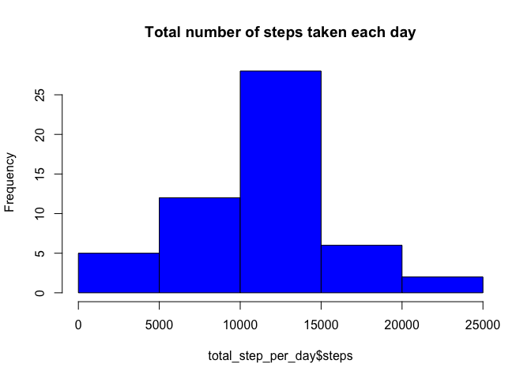

```r
hist(total_step_per_day$steps, main="Total number of steps taken each day", col="blue" )
```

Calculate and report the mean and median of the total number of steps taken per day

```r
mean(total_step_per_day$steps, na.rm=TRUE)
```

```
## [1] 10766.19
```

```r
median(total_step_per_day$steps, na.rm=TRUE)
```

```
## [1] 10765
```

## What is the average daily activity pattern?

Make a time series plot (i.e. type = “l”) of the 5-minute interval (x-axis) and the average number of steps taken, averaged across all days (y-axis)

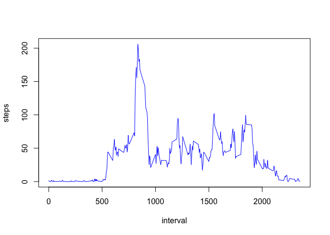

```r
interval_aggr <- aggregate(steps ~ interval, data = activity_data, mean, na.rm=TRUE)
plot(steps ~ interval, type = "l", data=interval_aggr, col="blue" )
```

Which 5-minute interval, on average across all the days in the dataset, contains the maximum number of steps?

```r
row_number <- which.max(interval_aggr$steps)
```

Therefore, interval 835 has the max number of steps which is 206.1698113

## Imputing missing values

Calculate and report the total number of missing values in the dataset (i.e. the total number of rows with NAs)

```r
is_na_table <- table(is.na(activity_data$steps))
```

Total number of missing values: 2304

Devise a strategy for filling in all of the missing values in the dataset. The strategy does not need to be sophisticated. For example, you could use the mean/median for that day, or the mean for that 5-minute interval, etc.

```r
#make a copy of the activity_data
activity_data_withNAfilled <- activity_data

#loop through row by row
for(i in 1:nrow(activity_data_withNAfilled)){
  #We only need to work on NA
  if(is.na(activity_data_withNAfilled[i,"steps"])){
    #fill the NA value with the mean of interval
    activity_data_withNAfilled[i,"steps"] <- interval_aggr[interval_aggr$interval==activity_data_withNAfilled[i,"interval"],"steps"]
  }
}

#Proof there is no more NA
table(is.na(activity_data_withNAfilled$steps))
```

```
##
## FALSE
## 17568
```

Make a histogram of the total number of steps taken each day

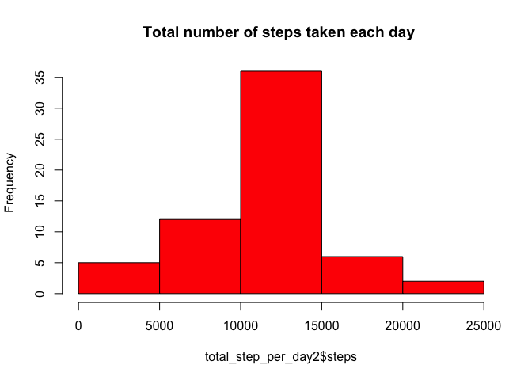

```r
total_step_per_day2 <- aggregate(steps ~ date, data=activity_data_withNAfilled, sum, na.rm=TRUE)
hist(total_step_per_day2$steps, main="Total number of steps taken each day ", col="red" )
```

mean

```r
mean(total_step_per_day2$steps, na.rm=TRUE)
```

```
## [1] 10766.19
```

medium

```r
median(total_step_per_day2$steps, na.rm=TRUE)
```

```
## [1] 10766.19
```

## Are there differences in activity patterns between weekdays and weekends?

Create a new factor variable in the dataset with two levels – “weekday” and “weekend” indicating whether a given date is a weekday or weekend day.

```r
#Create a new variable called day, weekdays would return Monday, Tuesday....
activity_data_withNAfilled$day <- weekdays(activity_data_withNAfilled$date)

weekday_or_weekend <- function(day){
  if(day == "Saturday" || day == "Sunday")
    "weekend"
  else
    "weekday"
}

#Loop through the list, add a variable to indicate if it is a weekday or not
activity_data_withNAfilled$weekday_weekend <- sapply(activity_data_withNAfilled$day, weekday_or_weekend)
```

Make a panel plot containing a time series plot (i.e. type = “l”) of the 5-minute interval (x-axis) and the average number of steps taken, averaged across all weekday days or weekend days (y-axis). See the README file in the GitHub repository to see an example of what this plot should look like using simulated data.

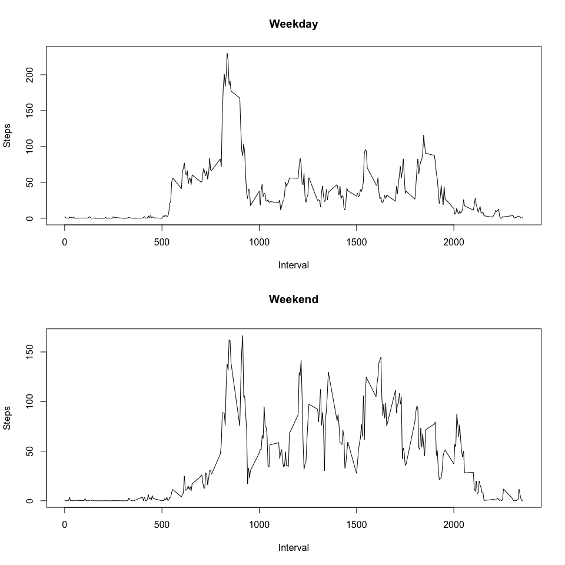

```r
weekday_weekend_aggr <- aggregate(steps ~ interval + weekday_weekend, data=activity_data_withNAfilled,mean)

par(mfrow=c(2,1))

#Weekday plot
  plot(x=weekday_weekend_aggr[weekday_weekend_aggr$weekday_weekend=="weekday",]$interval, y = weekday_weekend_aggr[weekday_weekend_aggr$weekday_weekend=="weekday",]$steps, type="l", main="Weekday", xlab="Interval", ylab="Steps")

  plot(x=weekday_weekend_aggr[weekday_weekend_aggr$weekday_weekend=="weekend",]$interval, y = weekday_weekend_aggr[weekday_weekend_aggr$weekday_weekend=="weekend",]$steps, type="l", main="Weekend
       ", xlab="Interval", ylab="Steps")
```